# Risk Factor Analysis

## Outcome Variable

**Outcome Variable:** ever_stunted

## Predictor Variables

**Intervention Variable:** single

**Adjustment Set:**

- arm
- W_mage
- meducyrs
- feducyrs
- W_mhtcm
- W_mwtkg
- W_mbmi
- delta_W_mage
- delta_meducyrs
- delta_feducyrs
- delta_W_mhtcm
- delta_W_mwtkg
- delta_W_mbmi

## Stratifying Variables

The analysis was stratified on these variable(s):

- agecat
- studyid
- country

## Data Summary

| agecat | studyid | country | single | ever_stunted | n_cell | n |
| --- | --- | --- | --- | --- | --- | --- |
| 0-24 months | COHORTS | GUATEMALA | 0 | 0 | 254 | 1207 |
| 0-24 months | COHORTS | GUATEMALA | 0 | 1 | 855 | 1207 |
| 0-24 months | COHORTS | GUATEMALA | 1 | 0 | 12 | 1207 |
| 0-24 months | COHORTS | GUATEMALA | 1 | 1 | 86 | 1207 |
| 0-24 months | COHORTS | INDIA | 0 | 0 | 3293 | 5384 |
| 0-24 months | COHORTS | INDIA | 0 | 1 | 2082 | 5384 |
| 0-24 months | COHORTS | INDIA | 1 | 0 | 4 | 5384 |
| 0-24 months | COHORTS | INDIA | 1 | 1 | 5 | 5384 |
| 0-24 months | COHORTS | PHILIPPINES | 0 | 0 | 924 | 3018 |
| 0-24 months | COHORTS | PHILIPPINES | 0 | 1 | 2019 | 3018 |
| 0-24 months | COHORTS | PHILIPPINES | 1 | 0 | 21 | 3018 |
| 0-24 months | COHORTS | PHILIPPINES | 1 | 1 | 54 | 3018 |
| 0-24 months | Guatemala BSC | GUATEMALA | 0 | 0 | 118 | 282 |
| 0-24 months | Guatemala BSC | GUATEMALA | 0 | 1 | 134 | 282 |
| 0-24 months | Guatemala BSC | GUATEMALA | 1 | 0 | 8 | 282 |
| 0-24 months | Guatemala BSC | GUATEMALA | 1 | 1 | 22 | 282 |
| 0-24 months | JiVitA-4 | BANGLADESH | 0 | 0 | 2263 | 5423 |
| 0-24 months | JiVitA-4 | BANGLADESH | 0 | 1 | 3152 | 5423 |
| 0-24 months | JiVitA-4 | BANGLADESH | 1 | 0 | 4 | 5423 |
| 0-24 months | JiVitA-4 | BANGLADESH | 1 | 1 | 4 | 5423 |
| 0-24 months | MAL-ED | BANGLADESH | 0 | 0 | 103 | 265 |
| 0-24 months | MAL-ED | BANGLADESH | 0 | 1 | 162 | 265 |
| 0-24 months | MAL-ED | BANGLADESH | 1 | 0 | 0 | 265 |
| 0-24 months | MAL-ED | BANGLADESH | 1 | 1 | 0 | 265 |
| 0-24 months | MAL-ED | BRAZIL | 0 | 0 | 148 | 233 |
| 0-24 months | MAL-ED | BRAZIL | 0 | 1 | 49 | 233 |
| 0-24 months | MAL-ED | BRAZIL | 1 | 0 | 22 | 233 |
| 0-24 months | MAL-ED | BRAZIL | 1 | 1 | 14 | 233 |
| 0-24 months | MAL-ED | INDIA | 0 | 0 | 99 | 249 |
| 0-24 months | MAL-ED | INDIA | 0 | 1 | 150 | 249 |

[output cut: 150 more lines]

The following strata were considered:

- agecat: 0-24 months, studyid: COHORTS, country: GUATEMALA
- agecat: 0-24 months, studyid: COHORTS, country: INDIA
- agecat: 0-24 months, studyid: COHORTS, country: PHILIPPINES
- agecat: 0-24 months, studyid: Guatemala BSC, country: GUATEMALA
- agecat: 0-24 months, studyid: JiVitA-4, country: BANGLADESH
- agecat: 0-24 months, studyid: MAL-ED, country: BANGLADESH
- agecat: 0-24 months, studyid: MAL-ED, country: BRAZIL
- agecat: 0-24 months, studyid: MAL-ED, country: INDIA
- agecat: 0-24 months, studyid: MAL-ED, country: NEPAL
- agecat: 0-24 months, studyid: MAL-ED, country: PERU
- agecat: 0-24 months, studyid: MAL-ED, country: SOUTH AFRICA
- agecat: 0-24 months, studyid: MAL-ED, country: TANZANIA, UNITED REPUBLIC OF
- agecat: 0-24 months, studyid: PROBIT, country: BELARUS
- agecat: 0-24 months, studyid: TanzaniaChild2, country: TANZANIA, UNITED REPUBLIC OF
- agecat: 0-24 months, studyid: ZVITAMBO, country: ZIMBABWE
- agecat: 0-6 months, studyid: COHORTS, country: GUATEMALA
- agecat: 0-6 months, studyid: COHORTS, country: INDIA
- agecat: 0-6 months, studyid: COHORTS, country: PHILIPPINES
- agecat: 0-6 months, studyid: Guatemala BSC, country: GUATEMALA
- agecat: 0-6 months, studyid: JiVitA-4, country: BANGLADESH
- agecat: 0-6 months, studyid: MAL-ED, country: BANGLADESH
- agecat: 0-6 months, studyid: MAL-ED, country: BRAZIL
- agecat: 0-6 months, studyid: MAL-ED, country: INDIA
- agecat: 0-6 months, studyid: MAL-ED, country: NEPAL
- agecat: 0-6 months, studyid: MAL-ED, country: PERU
- agecat: 0-6 months, studyid: MAL-ED, country: SOUTH AFRICA
- agecat: 0-6 months, studyid: MAL-ED, country: TANZANIA, UNITED REPUBLIC OF
- agecat: 0-6 months, studyid: PROBIT, country: BELARUS
- agecat: 0-6 months, studyid: TanzaniaChild2, country: TANZANIA, UNITED REPUBLIC OF
- agecat: 0-6 months, studyid: ZVITAMBO, country: ZIMBABWE
- agecat: 6-24 months, studyid: COHORTS, country: GUATEMALA
- agecat: 6-24 months, studyid: COHORTS, country: INDIA
- agecat: 6-24 months, studyid: COHORTS, country: PHILIPPINES
- agecat: 6-24 months, studyid: Guatemala BSC, country: GUATEMALA
- agecat: 6-24 months, studyid: JiVitA-4, country: BANGLADESH
- agecat: 6-24 months, studyid: MAL-ED, country: BANGLADESH
- agecat: 6-24 months, studyid: MAL-ED, country: BRAZIL
- agecat: 6-24 months, studyid: MAL-ED, country: INDIA
- agecat: 6-24 months, studyid: MAL-ED, country: NEPAL
- agecat: 6-24 months, studyid: MAL-ED, country: PERU
- agecat: 6-24 months, studyid: MAL-ED, country: SOUTH AFRICA
- agecat: 6-24 months, studyid: MAL-ED, country: TANZANIA, UNITED REPUBLIC OF
- agecat: 6-24 months, studyid: PROBIT, country: BELARUS
- agecat: 6-24 months, studyid: TanzaniaChild2, country: TANZANIA, UNITED REPUBLIC OF
- agecat: 6-24 months, studyid: ZVITAMBO, country: ZIMBABWE

### Dropped Strata

Some strata were dropped due to rare outcomes:

- agecat: 0-24 months, studyid: COHORTS, country: INDIA
- agecat: 0-24 months, studyid: JiVitA-4, country: BANGLADESH
- agecat: 0-24 months, studyid: MAL-ED, country: BANGLADESH
- agecat: 0-24 months, studyid: MAL-ED, country: INDIA
- agecat: 0-24 months, studyid: MAL-ED, country: NEPAL
- agecat: 0-24 months, studyid: MAL-ED, country: TANZANIA, UNITED REPUBLIC OF
- agecat: 0-6 months, studyid: COHORTS, country: INDIA
- agecat: 0-6 months, studyid: JiVitA-4, country: BANGLADESH
- agecat: 0-6 months, studyid: MAL-ED, country: BANGLADESH
- agecat: 0-6 months, studyid: MAL-ED, country: INDIA
- agecat: 0-6 months, studyid: MAL-ED, country: NEPAL
- agecat: 0-6 months, studyid: MAL-ED, country: TANZANIA, UNITED REPUBLIC OF
- agecat: 6-24 months, studyid: COHORTS, country: INDIA
- agecat: 6-24 months, studyid: JiVitA-4, country: BANGLADESH
- agecat: 6-24 months, studyid: MAL-ED, country: BANGLADESH
- agecat: 6-24 months, studyid: MAL-ED, country: BRAZIL
- agecat: 6-24 months, studyid: MAL-ED, country: INDIA
- agecat: 6-24 months, studyid: MAL-ED, country: NEPAL
- agecat: 6-24 months, studyid: MAL-ED, country: TANZANIA, UNITED REPUBLIC OF

## Methods Detail

We’re interested in the causal parameters $E[Y_a]$ for all values of $a \in \mathcal{A}$. These parameters represent the mean outcome if, possibly contrary to fact, we intervened to set all units to have $A=a$. Under the randomization and positivity assumptions, these are identified by the statistical parameters $\psi_a=E_W[E_{Y|A,W}(Y|A=a,W)]$. In addition, we’re interested in the mean of $Y$, $E[Y]$ under no intervention (the observed mean). We will estimate these parameters by using SuperLearner to fit the relevant likelihood factors – $E_{Y|A,W}(Y|A=a,W)$ and $p(A=a|W)$, and then updating our likelihood fit using a joint TMLE.

For unadjusted analyses ($W=\{\}$), initial likelihoods were estimated using Lrnr_glm to estimate the simple $E(Y|A)$ and Lrnr_mean to estimate $p(A)$. For adjusted analyses, a small library containing Lrnr_glmnet, Lrnr_xgboost, and Lrnr_mean was used.

Having estimated these parameters, we will then use the delta method to estimate relative risks and attributable risks relative to a prespecified baseline level of $A$.

# Results Detail

## Results Plots

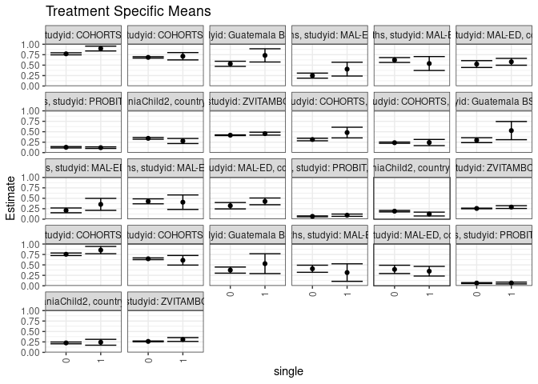

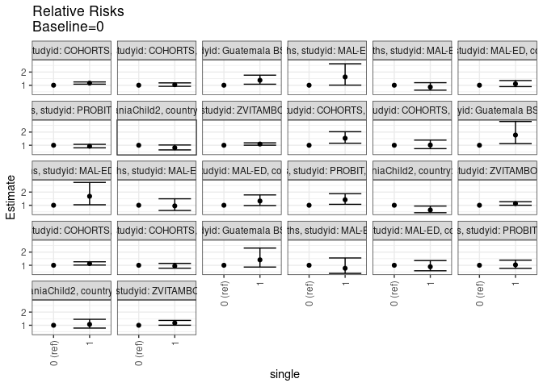

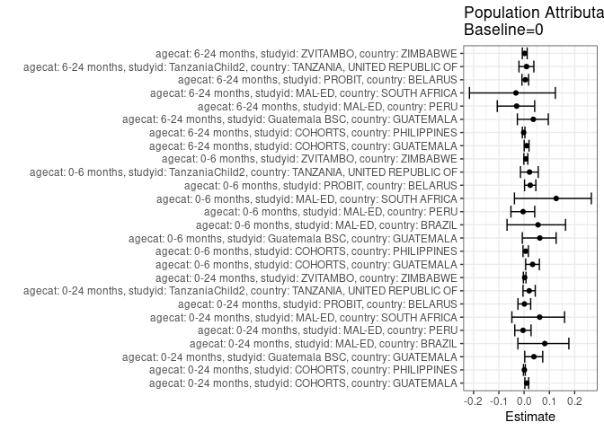

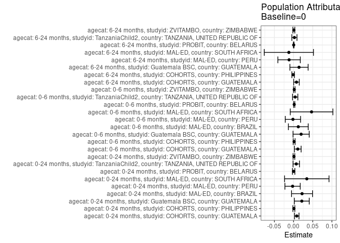

## Results Table

### Parameter: TSM

| agecat | studyid | country | intervention_level | baseline_level | estimate | ci_lower | ci_upper |
| --- | --- | --- | --- | --- | --- | --- | --- |
| 0-24 months | COHORTS | GUATEMALA | 0 | NA | 0.7713590 | 0.7466147 | 0.7961034 |
| 0-24 months | COHORTS | GUATEMALA | 1 | NA | 0.8975577 | 0.8398519 | 0.9552635 |
| 0-24 months | COHORTS | PHILIPPINES | 0 | NA | 0.6861687 | 0.6693217 | 0.7030156 |
| 0-24 months | COHORTS | PHILIPPINES | 1 | NA | 0.7135484 | 0.6255831 | 0.8015138 |
| 0-24 months | Guatemala BSC | GUATEMALA | 0 | NA | 0.5317460 | 0.4700280 | 0.5934641 |
| 0-24 months | Guatemala BSC | GUATEMALA | 1 | NA | 0.7333333 | 0.5748097 | 0.8918569 |
| 0-24 months | MAL-ED | BRAZIL | 0 | NA | 0.2482813 | 0.1878160 | 0.3087465 |
| 0-24 months | MAL-ED | BRAZIL | 1 | NA | 0.4042789 | 0.2388667 | 0.5696911 |
| 0-24 months | MAL-ED | PERU | 0 | NA | 0.6230747 | 0.5649688 | 0.6811807 |
| 0-24 months | MAL-ED | PERU | 1 | NA | 0.5386038 | 0.3717166 | 0.7054910 |
| 0-24 months | MAL-ED | SOUTH AFRICA | 0 | NA | 0.5259818 | 0.4442996 | 0.6076639 |
| 0-24 months | MAL-ED | SOUTH AFRICA | 1 | NA | 0.5800514 | 0.4979114 | 0.6621914 |
| 0-24 months | PROBIT | BELARUS | 0 | NA | 0.1272735 | 0.1106732 | 0.1438739 |
| 0-24 months | PROBIT | BELARUS | 1 | NA | 0.1179575 | 0.0990159 | 0.1368992 |
| 0-24 months | TanzaniaChild2 | TANZANIA, UNITED REPUBLIC OF | 0 | NA | 0.3412142 | 0.3201668 | 0.3622615 |
| 0-24 months | TanzaniaChild2 | TANZANIA, UNITED REPUBLIC OF | 1 | NA | 0.2771305 | 0.2163675 | 0.3378935 |
| 0-24 months | ZVITAMBO | ZIMBABWE | 0 | NA | 0.4163125 | 0.4078688 | 0.4247562 |
| 0-24 months | ZVITAMBO | ZIMBABWE | 1 | NA | 0.4536837 | 0.4182917 | 0.4890756 |
| 0-6 months | COHORTS | GUATEMALA | 0 | NA | 0.3135246 | 0.2832482 | 0.3438010 |
| 0-6 months | COHORTS | GUATEMALA | 1 | NA | 0.4795736 | 0.3518346 | 0.6073127 |
| 0-6 months | COHORTS | PHILIPPINES | 0 | NA | 0.2370711 | 0.2216050 | 0.2525371 |
| 0-6 months | COHORTS | PHILIPPINES | 1 | NA | 0.2411561 | 0.1669393 | 0.3153728 |
| 0-6 months | Guatemala BSC | GUATEMALA | 0 | NA | 0.2972758 | 0.2387911 | 0.3557606 |
| 0-6 months | Guatemala BSC | GUATEMALA | 1 | NA | 0.5272207 | 0.3091504 | 0.7452911 |
| 0-6 months | MAL-ED | BRAZIL | 0 | NA | 0.2108503 | 0.1538082 | 0.2678924 |
| 0-6 months | MAL-ED | BRAZIL | 1 | NA | 0.3547568 | 0.2113982 | 0.4981154 |
| 0-6 months | MAL-ED | PERU | 0 | NA | 0.4274505 | 0.3681050 | 0.4867960 |
| 0-6 months | MAL-ED | PERU | 1 | NA | 0.4066317 | 0.2330174 | 0.5802461 |
| 0-6 months | MAL-ED | SOUTH AFRICA | 0 | NA | 0.3224927 | 0.2461021 | 0.3988832 |
| 0-6 months | MAL-ED | SOUTH AFRICA | 1 | NA | 0.4264436 | 0.3457844 | 0.5071027 |
| 0-6 months | PROBIT | BELARUS | 0 | NA | 0.0669450 | 0.0560789 | 0.0778112 |
| 0-6 months | PROBIT | BELARUS | 1 | NA | 0.0949778 | 0.0673215 | 0.1226342 |
| 0-6 months | TanzaniaChild2 | TANZANIA, UNITED REPUBLIC OF | 0 | NA | 0.1915849 | 0.1742332 | 0.2089366 |
| 0-6 months | TanzaniaChild2 | TANZANIA, UNITED REPUBLIC OF | 1 | NA | 0.1227082 | 0.0766932 | 0.1687233 |
| 0-6 months | ZVITAMBO | ZIMBABWE | 0 | NA | 0.2570198 | 0.2495165 | 0.2645232 |
| 0-6 months | ZVITAMBO | ZIMBABWE | 1 | NA | 0.2899790 | 0.2565434 | 0.3234146 |
| 6-24 months | COHORTS | GUATEMALA | 0 | NA | 0.7546174 | 0.7239651 | 0.7852698 |
| 6-24 months | COHORTS | GUATEMALA | 1 | NA | 0.8548387 | 0.7671013 | 0.9425761 |
| 6-24 months | COHORTS | PHILIPPINES | 0 | NA | 0.6463590 | 0.6255251 | 0.6671928 |
| 6-24 months | COHORTS | PHILIPPINES | 1 | NA | 0.6105161 | 0.4949144 | 0.7261178 |
| 6-24 months | Guatemala BSC | GUATEMALA | 0 | NA | 0.3750000 | 0.3015949 | 0.4484051 |
| 6-24 months | Guatemala BSC | GUATEMALA | 1 | NA | 0.5294118 | 0.2914989 | 0.7673246 |
| 6-24 months | MAL-ED | PERU | 0 | NA | 0.4076923 | 0.3229347 | 0.4924499 |
| 6-24 months | MAL-ED | PERU | 1 | NA | 0.3157895 | 0.1060755 | 0.5255034 |
| 6-24 months | MAL-ED | SOUTH AFRICA | 0 | NA | 0.3920587 | 0.2924332 | 0.4916842 |
| 6-24 months | MAL-ED | SOUTH AFRICA | 1 | NA | 0.3487182 | 0.2327258 | 0.4647106 |
| 6-24 months | PROBIT | BELARUS | 0 | NA | 0.0639598 | 0.0522587 | 0.0756609 |
| 6-24 months | PROBIT | BELARUS | 1 | NA | 0.0660277 | 0.0447505 | 0.0873048 |
| 6-24 months | TanzaniaChild2 | TANZANIA, UNITED REPUBLIC OF | 0 | NA | 0.2256490 | 0.2040537 | 0.2472442 |
| 6-24 months | TanzaniaChild2 | TANZANIA, UNITED REPUBLIC OF | 1 | NA | 0.2413932 | 0.1707741 | 0.3120124 |
| 6-24 months | ZVITAMBO | ZIMBABWE | 0 | NA | 0.2622999 | 0.2526096 | 0.2719901 |
| 6-24 months | ZVITAMBO | ZIMBABWE | 1 | NA | 0.3074995 | 0.2617250 | 0.3532740 |

### Parameter: E(Y)

| agecat | studyid | country | intervention_level | baseline_level | estimate | ci_lower | ci_upper |
| --- | --- | --- | --- | --- | --- | --- | --- |
| 0-24 months | COHORTS | GUATEMALA | NA | NA | 0.7796189 | 0.7562250 | 0.8030128 |
| 0-24 months | COHORTS | PHILIPPINES | NA | NA | 0.6868787 | 0.6703303 | 0.7034272 |
| 0-24 months | Guatemala BSC | GUATEMALA | NA | NA | 0.5531915 | 0.4950624 | 0.6113206 |
| 0-24 months | MAL-ED | BRAZIL | NA | NA | 0.2703863 | 0.2132328 | 0.3275398 |
| 0-24 months | MAL-ED | PERU | NA | NA | 0.6204620 | 0.5657315 | 0.6751926 |
| 0-24 months | MAL-ED | SOUTH AFRICA | NA | NA | 0.5605096 | 0.5055248 | 0.6154943 |
| 0-24 months | PROBIT | BELARUS | NA | NA | 0.1274191 | 0.1115552 | 0.1432829 |
| 0-24 months | TanzaniaChild2 | TANZANIA, UNITED REPUBLIC OF | NA | NA | 0.3482105 | 0.3290467 | 0.3673744 |
| 0-24 months | ZVITAMBO | ZIMBABWE | NA | NA | 0.4172374 | 0.4090737 | 0.4254012 |
| 0-6 months | COHORTS | GUATEMALA | NA | NA | 0.3244353 | 0.2950189 | 0.3538517 |
| 0-6 months | COHORTS | PHILIPPINES | NA | NA | 0.2385686 | 0.2233602 | 0.2537770 |
| 0-6 months | Guatemala BSC | GUATEMALA | NA | NA | 0.3169811 | 0.2608532 | 0.3731091 |
| 0-6 months | MAL-ED | BRAZIL | NA | NA | 0.2231760 | 0.1695976 | 0.2767543 |
| 0-6 months | MAL-ED | PERU | NA | NA | 0.4257426 | 0.3699763 | 0.4815088 |
| 0-6 months | MAL-ED | SOUTH AFRICA | NA | NA | 0.3694268 | 0.3159570 | 0.4228965 |
| 0-6 months | PROBIT | BELARUS | NA | NA | 0.0686124 | 0.0577768 | 0.0794479 |
| 0-6 months | TanzaniaChild2 | TANZANIA, UNITED REPUBLIC OF | NA | NA | 0.1957895 | 0.1798275 | 0.2117515 |
| 0-6 months | ZVITAMBO | ZIMBABWE | NA | NA | 0.2588042 | 0.2515487 | 0.2660597 |
| 6-24 months | COHORTS | GUATEMALA | NA | NA | 0.7621951 | 0.7330377 | 0.7913526 |
| 6-24 months | COHORTS | PHILIPPINES | NA | NA | 0.6452074 | 0.6247246 | 0.6656902 |
| 6-24 months | Guatemala BSC | GUATEMALA | NA | NA | 0.3891892 | 0.3187405 | 0.4596379 |
| 6-24 months | MAL-ED | PERU | NA | NA | 0.3959732 | 0.3171819 | 0.4747644 |
| 6-24 months | MAL-ED | SOUTH AFRICA | NA | NA | 0.3797468 | 0.3038314 | 0.4556622 |
| 6-24 months | PROBIT | BELARUS | NA | NA | 0.0642659 | 0.0526827 | 0.0758490 |
| 6-24 months | TanzaniaChild2 | TANZANIA, UNITED REPUBLIC OF | NA | NA | 0.2278162 | 0.2071874 | 0.2484451 |
| 6-24 months | ZVITAMBO | ZIMBABWE | NA | NA | 0.2629713 | 0.2535901 | 0.2723525 |

### Parameter: RR

| agecat | studyid | country | intervention_level | baseline_level | estimate | ci_lower | ci_upper |
| --- | --- | --- | --- | --- | --- | --- | --- |
| 0-24 months | COHORTS | GUATEMALA | 0 | 0 | 1.0000000 | 1.0000000 | 1.0000000 |
| 0-24 months | COHORTS | GUATEMALA | 1 | 0 | 1.1636056 | 1.0831206 | 1.2500714 |
| 0-24 months | COHORTS | PHILIPPINES | 0 | 0 | 1.0000000 | 1.0000000 | 1.0000000 |
| 0-24 months | COHORTS | PHILIPPINES | 1 | 0 | 1.0399024 | 0.9172131 | 1.1790030 |
| 0-24 months | Guatemala BSC | GUATEMALA | 0 | 0 | 1.0000000 | 1.0000000 | 1.0000000 |
| 0-24 months | Guatemala BSC | GUATEMALA | 1 | 0 | 1.3791045 | 1.0790454 | 1.7626034 |
| 0-24 months | MAL-ED | BRAZIL | 0 | 0 | 1.0000000 | 1.0000000 | 1.0000000 |
| 0-24 months | MAL-ED | BRAZIL | 1 | 0 | 1.6283099 | 1.0098085 | 2.6256396 |
| 0-24 months | MAL-ED | PERU | 0 | 0 | 1.0000000 | 1.0000000 | 1.0000000 |
| 0-24 months | MAL-ED | PERU | 1 | 0 | 0.8644289 | 0.6255840 | 1.1944635 |
| 0-24 months | MAL-ED | SOUTH AFRICA | 0 | 0 | 1.0000000 | 1.0000000 | 1.0000000 |
| 0-24 months | MAL-ED | SOUTH AFRICA | 1 | 0 | 1.1027975 | 0.8960663 | 1.3572237 |
| 0-24 months | PROBIT | BELARUS | 0 | 0 | 1.0000000 | 1.0000000 | 1.0000000 |
| 0-24 months | PROBIT | BELARUS | 1 | 0 | 0.9268034 | 0.8041910 | 1.0681101 |
| 0-24 months | TanzaniaChild2 | TANZANIA, UNITED REPUBLIC OF | 0 | 0 | 1.0000000 | 1.0000000 | 1.0000000 |
| 0-24 months | TanzaniaChild2 | TANZANIA, UNITED REPUBLIC OF | 1 | 0 | 0.8121893 | 0.6471190 | 1.0193665 |
| 0-24 months | ZVITAMBO | ZIMBABWE | 0 | 0 | 1.0000000 | 1.0000000 | 1.0000000 |
| 0-24 months | ZVITAMBO | ZIMBABWE | 1 | 0 | 1.0897671 | 1.0056261 | 1.1809481 |
| 0-6 months | COHORTS | GUATEMALA | 0 | 0 | 1.0000000 | 1.0000000 | 1.0000000 |
| 0-6 months | COHORTS | GUATEMALA | 1 | 0 | 1.5296203 | 1.1545465 | 2.0265429 |
| 0-6 months | COHORTS | PHILIPPINES | 0 | 0 | 1.0000000 | 1.0000000 | 1.0000000 |
| 0-6 months | COHORTS | PHILIPPINES | 1 | 0 | 1.0172312 | 0.7435173 | 1.3917085 |
| 0-6 months | Guatemala BSC | GUATEMALA | 0 | 0 | 1.0000000 | 1.0000000 | 1.0000000 |
| 0-6 months | Guatemala BSC | GUATEMALA | 1 | 0 | 1.7735068 | 1.1234065 | 2.7998116 |
| 0-6 months | MAL-ED | BRAZIL | 0 | 0 | 1.0000000 | 1.0000000 | 1.0000000 |
| 0-6 months | MAL-ED | BRAZIL | 1 | 0 | 1.6825055 | 1.0354499 | 2.7339078 |
| 0-6 months | MAL-ED | PERU | 0 | 0 | 1.0000000 | 1.0000000 | 1.0000000 |
| 0-6 months | MAL-ED | PERU | 1 | 0 | 0.9512955 | 0.6072744 | 1.4902045 |
| 0-6 months | MAL-ED | SOUTH AFRICA | 0 | 0 | 1.0000000 | 1.0000000 | 1.0000000 |
| 0-6 months | MAL-ED | SOUTH AFRICA | 1 | 0 | 1.3223356 | 0.9801541 | 1.7839761 |
| 0-6 months | PROBIT | BELARUS | 0 | 0 | 1.0000000 | 1.0000000 | 1.0000000 |
| 0-6 months | PROBIT | BELARUS | 1 | 0 | 1.4187436 | 1.0714020 | 1.8786911 |
| 0-6 months | TanzaniaChild2 | TANZANIA, UNITED REPUBLIC OF | 0 | 0 | 1.0000000 | 1.0000000 | 1.0000000 |
| 0-6 months | TanzaniaChild2 | TANZANIA, UNITED REPUBLIC OF | 1 | 0 | 0.6404901 | 0.4357913 | 0.9413395 |
| 0-6 months | ZVITAMBO | ZIMBABWE | 0 | 0 | 1.0000000 | 1.0000000 | 1.0000000 |
| 0-6 months | ZVITAMBO | ZIMBABWE | 1 | 0 | 1.1282360 | 1.0019292 | 1.2704655 |
| 6-24 months | COHORTS | GUATEMALA | 0 | 0 | 1.0000000 | 1.0000000 | 1.0000000 |
| 6-24 months | COHORTS | GUATEMALA | 1 | 0 | 1.1328107 | 1.0144231 | 1.2650147 |
| 6-24 months | COHORTS | PHILIPPINES | 0 | 0 | 1.0000000 | 1.0000000 | 1.0000000 |
| 6-24 months | COHORTS | PHILIPPINES | 1 | 0 | 0.9445465 | 0.7795781 | 1.1444243 |
| 6-24 months | Guatemala BSC | GUATEMALA | 0 | 0 | 1.0000000 | 1.0000000 | 1.0000000 |
| 6-24 months | Guatemala BSC | GUATEMALA | 1 | 0 | 1.4117647 | 0.8647352 | 2.3048439 |
| 6-24 months | MAL-ED | PERU | 0 | 0 | 1.0000000 | 1.0000000 | 1.0000000 |
| 6-24 months | MAL-ED | PERU | 1 | 0 | 0.7745780 | 0.3862340 | 1.5533872 |
| 6-24 months | MAL-ED | SOUTH AFRICA | 0 | 0 | 1.0000000 | 1.0000000 | 1.0000000 |
| 6-24 months | MAL-ED | SOUTH AFRICA | 1 | 0 | 0.8894541 | 0.5836198 | 1.3555547 |
| 6-24 months | PROBIT | BELARUS | 0 | 0 | 1.0000000 | 1.0000000 | 1.0000000 |
| 6-24 months | PROBIT | BELARUS | 1 | 0 | 1.0323304 | 0.7676235 | 1.3883187 |
| 6-24 months | TanzaniaChild2 | TANZANIA, UNITED REPUBLIC OF | 0 | 0 | 1.0000000 | 1.0000000 | 1.0000000 |
| 6-24 months | TanzaniaChild2 | TANZANIA, UNITED REPUBLIC OF | 1 | 0 | 1.0697733 | 0.7866651 | 1.4547676 |
| 6-24 months | ZVITAMBO | ZIMBABWE | 0 | 0 | 1.0000000 | 1.0000000 | 1.0000000 |
| 6-24 months | ZVITAMBO | ZIMBABWE | 1 | 0 | 1.1723204 | 1.0057554 | 1.3664704 |

### Parameter: PAR

| agecat | studyid | country | intervention_level | baseline_level | estimate | ci_lower | ci_upper |
| --- | --- | --- | --- | --- | --- | --- | --- |
| 0-24 months | COHORTS | GUATEMALA | 0 | NA | 0.0082599 | 0.0023764 | 0.0141433 |
| 0-24 months | COHORTS | PHILIPPINES | 0 | NA | 0.0007101 | -0.0018264 | 0.0032465 |
| 0-24 months | Guatemala BSC | GUATEMALA | 0 | NA | 0.0214455 | 0.0019436 | 0.0409473 |
| 0-24 months | MAL-ED | BRAZIL | 0 | NA | 0.0221050 | -0.0052707 | 0.0494807 |
| 0-24 months | MAL-ED | PERU | 0 | NA | -0.0026127 | -0.0225969 | 0.0173715 |
| 0-24 months | MAL-ED | SOUTH AFRICA | 0 | NA | 0.0345278 | -0.0235273 | 0.0925829 |
| 0-24 months | PROBIT | BELARUS | 0 | NA | 0.0001455 | -0.0030546 | 0.0033457 |
| 0-24 months | TanzaniaChild2 | TANZANIA, UNITED REPUBLIC OF | 0 | NA | 0.0069964 | -0.0014273 | 0.0154200 |
| 0-24 months | ZVITAMBO | ZIMBABWE | 0 | NA | 0.0009249 | -0.0012552 | 0.0031051 |
| 0-6 months | COHORTS | GUATEMALA | 0 | NA | 0.0109107 | 0.0021140 | 0.0197074 |
| 0-6 months | COHORTS | PHILIPPINES | 0 | NA | 0.0014975 | -0.0010210 | 0.0040161 |
| 0-6 months | Guatemala BSC | GUATEMALA | 0 | NA | 0.0197053 | -0.0014484 | 0.0408589 |
| 0-6 months | MAL-ED | BRAZIL | 0 | NA | 0.0123257 | -0.0135788 | 0.0382301 |
| 0-6 months | MAL-ED | PERU | 0 | NA | -0.0017079 | -0.0217238 | 0.0183080 |
| 0-6 months | MAL-ED | SOUTH AFRICA | 0 | NA | 0.0469341 | -0.0087081 | 0.1025763 |
| 0-6 months | PROBIT | BELARUS | 0 | NA | 0.0016673 | 0.0001471 | 0.0031876 |
| 0-6 months | TanzaniaChild2 | TANZANIA, UNITED REPUBLIC OF | 0 | NA | 0.0042046 | -0.0026704 | 0.0110795 |
| 0-6 months | ZVITAMBO | ZIMBABWE | 0 | NA | 0.0017844 | -0.0002335 | 0.0038023 |
| 6-24 months | COHORTS | GUATEMALA | 0 | NA | 0.0075777 | 0.0003202 | 0.0148352 |
| 6-24 months | COHORTS | PHILIPPINES | 0 | NA | -0.0011515 | -0.0044905 | 0.0021875 |
| 6-24 months | Guatemala BSC | GUATEMALA | 0 | NA | 0.0141892 | -0.0095805 | 0.0379589 |
| 6-24 months | MAL-ED | PERU | 0 | NA | -0.0117192 | -0.0409824 | 0.0175441 |
| 6-24 months | MAL-ED | SOUTH AFRICA | 0 | NA | -0.0123119 | -0.0765264 | 0.0519026 |
| 6-24 months | PROBIT | BELARUS | 0 | NA | 0.0003060 | -0.0005276 | 0.0011397 |
| 6-24 months | TanzaniaChild2 | TANZANIA, UNITED REPUBLIC OF | 0 | NA | 0.0021673 | -0.0045357 | 0.0088703 |
| 6-24 months | ZVITAMBO | ZIMBABWE | 0 | NA | 0.0006714 | -0.0018499 | 0.0031927 |

### Parameter: PAF

| agecat | studyid | country | intervention_level | baseline_level | estimate | ci_lower | ci_upper |
| --- | --- | --- | --- | --- | --- | --- | --- |
| 0-24 months | COHORTS | GUATEMALA | 0 | NA | 0.0105947 | 0.0029773 | 0.0181540 |
| 0-24 months | COHORTS | PHILIPPINES | 0 | NA | 0.0010337 | -0.0026669 | 0.0047207 |
| 0-24 months | Guatemala BSC | GUATEMALA | 0 | NA | 0.0387668 | 0.0025234 | 0.0736932 |
| 0-24 months | MAL-ED | BRAZIL | 0 | NA | 0.0817533 | -0.0247121 | 0.1771572 |
| 0-24 months | MAL-ED | PERU | 0 | NA | -0.0042109 | -0.0369469 | 0.0274917 |
| 0-24 months | MAL-ED | SOUTH AFRICA | 0 | NA | 0.0616007 | -0.0483972 | 0.1600577 |
| 0-24 months | PROBIT | BELARUS | 0 | NA | 0.0011423 | -0.0243114 | 0.0259635 |
| 0-24 months | TanzaniaChild2 | TANZANIA, UNITED REPUBLIC OF | 0 | NA | 0.0200924 | -0.0044426 | 0.0440280 |
| 0-24 months | ZVITAMBO | ZIMBABWE | 0 | NA | 0.0022168 | -0.0030221 | 0.0074284 |
| 0-6 months | COHORTS | GUATEMALA | 0 | NA | 0.0336298 | 0.0061134 | 0.0603843 |
| 0-6 months | COHORTS | PHILIPPINES | 0 | NA | 0.0062772 | -0.0043520 | 0.0167939 |
| 0-6 months | Guatemala BSC | GUATEMALA | 0 | NA | 0.0621655 | -0.0070928 | 0.1266609 |
| 0-6 months | MAL-ED | BRAZIL | 0 | NA | 0.0552284 | -0.0675744 | 0.1639053 |
| 0-6 months | MAL-ED | PERU | 0 | NA | -0.0040116 | -0.0521441 | 0.0419191 |
| 0-6 months | MAL-ED | SOUTH AFRICA | 0 | NA | 0.1270457 | -0.0382392 | 0.2660177 |
| 0-6 months | PROBIT | BELARUS | 0 | NA | 0.0243008 | 0.0017474 | 0.0463447 |
| 0-6 months | TanzaniaChild2 | TANZANIA, UNITED REPUBLIC OF | 0 | NA | 0.0214749 | -0.0143140 | 0.0560011 |
| 0-6 months | ZVITAMBO | ZIMBABWE | 0 | NA | 0.0068947 | -0.0009326 | 0.0146608 |
| 6-24 months | COHORTS | GUATEMALA | 0 | NA | 0.0099420 | 0.0003332 | 0.0194583 |
| 6-24 months | COHORTS | PHILIPPINES | 0 | NA | -0.0017847 | -0.0069721 | 0.0033759 |
| 6-24 months | Guatemala BSC | GUATEMALA | 0 | NA | 0.0364583 | -0.0266802 | 0.0957140 |
| 6-24 months | MAL-ED | PERU | 0 | NA | -0.0295958 | -0.1063031 | 0.0417928 |
| 6-24 months | MAL-ED | SOUTH AFRICA | 0 | NA | -0.0324213 | -0.2162718 | 0.1236385 |
| 6-24 months | PROBIT | BELARUS | 0 | NA | 0.0047620 | -0.0084152 | 0.0177670 |
| 6-24 months | TanzaniaChild2 | TANZANIA, UNITED REPUBLIC OF | 0 | NA | 0.0095132 | -0.0203508 | 0.0385032 |
| 6-24 months | ZVITAMBO | ZIMBABWE | 0 | NA | 0.0025531 | -0.0070804 | 0.0120945 |